# Curve fit results

Emil Bjerglund Pedersen

2017-03-30

Raman data can be tedious to import and analyse, when exported from Renishaw Wire. I found myself writing similar pieces of code over an over, to solve the same problems and have collected it all in this R package for easy use. This document will demonstrate how to work with **curve fit results**. Another vignette is available describing functions for spectral maps.

## Importing data

Curve fit results from wire can be exported to a set of `.txt` files. The files should be saved indicating the peak and corresponding feature, e.g. `2D FWHM.txt` for the Full-width at Half-max of the 2D peak (use `int` for intensity and `pos` for position).

The package includes some sample data that will be used for demonstration purposes. `cf_folder` should point to the folder containing your curve fit results.

```r
library(tidyverse)
library(gRaphene)

cf_folder <- system.file("extdata/graphene_curve_fit_export", package = "gRaphene")
data_cf <- gr_cf_read(cf_folder)
```

Common graphene ratios (`D/G`, `2D/G` and `D/Dp`) will automatically be calculated if the right peaks are present.

## Summary statistics

The data can be summarised easily by using `gr_cf_summary(data_cf)`. The example used here contains a mix of SiO2 and graphene flakes, so in some cases i use `filter()` or `mutate()` to deal with values that are outside the expected ranges.

```r
data_cf_filtered <- data_cf %>% filter(`G int` > 50) %>% select(-starts_with('SiO2'))

knitr::kable(
  gr_cf_summary(data_cf_filtered),
  digits = c(0, 1, 0, 1, 1, 0, 1, 1, 0, 1, 2, 2)
)
```

| key | 2D FWHM | 2D int | 2D pos | D FWHM | D int | D pos | G FWHM | G int | G pos | D/G-ratio | 2D/G-ratio |
| --- | --- | --- | --- | --- | --- | --- | --- | --- | --- | --- | --- |
| min | 78.5 | 6 | 2680.0 | 57.2 | 55 | 1349.0 | 41.7 | 50 | 1579.4 | 0.99 | 0.10 |
| mean | 115.6 | 50 | 2698.4 | 68.1 | 311 | 1352.6 | 50.7 | 250 | 1588.9 | 1.26 | 0.19 |
| max | 187.1 | 121 | 2716.6 | 89.0 | 661 | 1356.3 | 69.5 | 573 | 1594.1 | 1.54 | 0.26 |
| sd | 14.7 | 28 | 3.8 | 5.6 | 140 | 0.7 | 3.3 | 122 | 1.2 | 0.09 | 0.02 |

## Plotting curve fits

Getting an overview of the data from curve-fits can be challenging. The `gr_cf_plot` accepts a data-frame with columns `x`, `y` and a `value` and plots a map. Arguments can be passed to change appearance of the plot and size of the scalebar. See available color schemes by running the command `RColorBrewer::display.brewer.all()`.

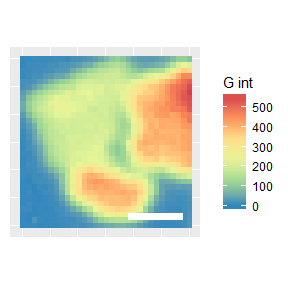

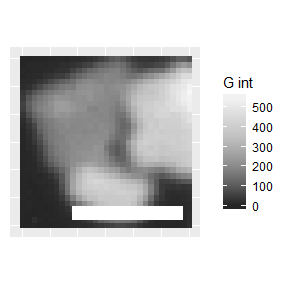

```r
data_cf_small <- data_cf %>% select(x, y, `G int`) %>% rename(value = `G int`)
gr_cf_plot(df = data_cf_small, name = 'G int')
gr_cf_plot(df = data_cf_small, name = 'G int', scalebar = 2, palette = "Greys")
```

A whole range of maps can be plotted by supplying a data-frame to `gr_cf_plot_all()` as in the following example. This function also accepts the `scalebar` and `palette` arguments.

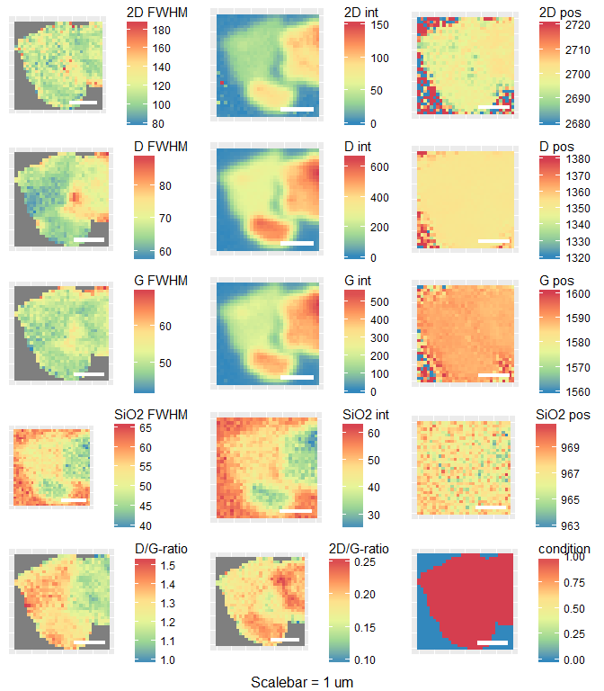

```r
data_cf %>%
  mutate(condition = `G int` > 50) %>%
  mutate(`2D FWHM` = ifelse(condition, `2D FWHM`, NA)) %>%
  mutate(`D FWHM` = ifelse(condition, `D FWHM`, NA)) %>%
  mutate(`G FWHM` = ifelse(condition, `G FWHM`, NA)) %>%
  mutate(`D/G-ratio` = ifelse(condition, `D/G-ratio`, NA)) %>%
  mutate(`2D/G-ratio` = ifelse(condition, `2D/G-ratio`, NA)) %>%
  gr_cf_plot_all()
```

## Plotting curve-fitted spectra

In some cases it is desireable to present the results of a curve-fit on a spectrum as an example. This is possible using `gr_cf_fit_add()` and `gr_cf_fit_plot()`. It is necessary to have two files:

1. A spectrum in a tab-separated text file (as exported by Wire) containing columns with wavenumber and intensity.
2. A text-file with Curve fit results, which is also exported from Wire by right-clicking the results-table after a curve fit and choosing ‘Copy Results’.

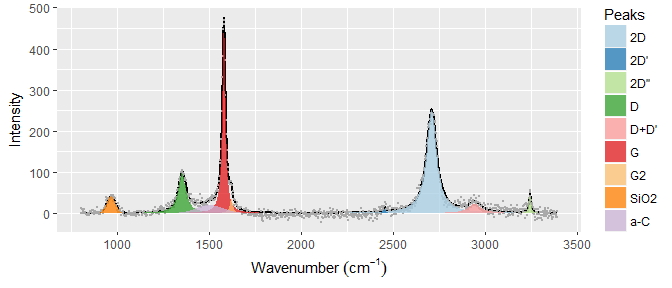

```r
curvefit <- system.file("extdata/curvefit_data.txt", package = "gRaphene")
spectrum <- system.file("extdata/spectrum_example.txt", package = "gRaphene")

gr_cf_fit_plot(spectrum, curvefit)
```

The object returned by `gr_cf_fit_plot()` is an ordinary ggplot2 object, and can be modified by adding new layers.

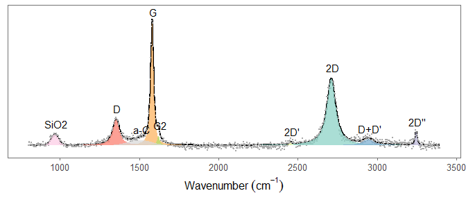

```r
gr_cf_ann <- gr_cf_fit_add(spectrum, curvefit) %>%
  select(-intensity, -envelope) %>%
  gather(key = "peak", value = "intensity", -wavenumber) %>%
  group_by(peak) %>%
  filter(intensity == max(intensity))

gr_cf_fit_plot(spectrum, curvefit) +
  ggthemes::theme_few() +
  theme(axis.title.y = element_blank(),
        axis.text.y = element_blank(),
        axis.ticks.y = element_blank(),
        legend.position = "none") +
  scale_fill_brewer(palette = "Set3", guide = guide_legend(nrow = 1)) +
  geom_text(data = gr_cf_ann, aes(x = wavenumber, y = intensity, label = peak), nudge_y = 40, nudge_x = 10)
```

Finally, if you wish to generate your completely own plot, just use `gr_cf_fit_add()` to generate the fitted data, and plot it manually.

```r
fit_data <- gr_cf_fit_add(spectrum, curvefit)

knitr::kable(head(fit_data, 5), digits = 3)
```

| wavenumber | intensity | SiO2 | D | G | 2D’ | 2D | 2D’’ | D+D’ | a-C | G2 | envelope |
| --- | --- | --- | --- | --- | --- | --- | --- | --- | --- | --- | --- |
| 3394.312 | -9.938 | 0 | 0.015 | 0.016 | 0.001 | 0.618 | 0.095 | 0.199 | 0 | 0.001 | 0.946 |
| 3392.120 | 4.974 | 0 | 0.016 | 0.016 | 0.001 | 0.622 | 0.098 | 0.201 | 0 | 0.001 | 0.955 |
| 3389.928 | -7.486 | 0 | 0.016 | 0.016 | 0.001 | 0.626 | 0.101 | 0.203 | 0 | 0.001 | 0.964 |
| 3387.734 | -1.703 | 0 | 0.016 | 0.016 | 0.001 | 0.630 | 0.104 | 0.205 | 0 | 0.001 | 0.973 |
| 3385.540 | -9.597 | 0 | 0.016 | 0.016 | 0.001 | 0.634 | 0.108 | 0.207 | 0 | 0.001 | 0.983 |